# רנסנס של מידע תחבורתי - כמה נוסעים פוטנציאלים יש לקו האדום של הרכבת הקלה?

דר’ עדו קליין

# מטרת ההרצאה

להבין כיצד ניתן, באמצעות הנתונים התחבורתיים הפתוחים כיום למתכנני תחבורה ולמתכננים בכלל, לענות על שאלות תחבורתיות מורכבות.

# השאלות

כמה נוסעים פוטנציאלים יש לקו האדום של הרכבת הקלה בתל אביב, ביום היפתחה?

מהו המרחק שנוסעים אלו נוסעים כיום?

באלו שעות ביום נסיעות אלו מתבצעות?

באלו אמצעים נסיעות אלו מתבצעות כיום?

מה גיל הנוסעים כיום?

מהו מגזר הנוסעים כיום?

# מקורות שיסייעו לנו לענות על השאלה

### חצב

### תלתן

### data gov

# חצב

הgis לצורכי תכנון של משרד התחבורה.

מחובר לgovmap, הממשק הGISי של מפ"י

מכיל מידע מגוון מאוד - ממצב פרויקטים, לתכנון, לתשתיות, לנתונים כללים.

מיועד בעיקר לצפייה והורדה של מידע. לא ניתוח.

כן מכיל ממשק ניתוח בהקשר של פרויקטים תחבורתיים.

[קישור לחצב](https://geo.mot.gov.il/)

# תלתן

חיבור של מערכות הGIS של צוות אב לתחבורה, נתיבי איילון ויפה נוף.

מתוחזק על ידי חברת PGL, בהנחית הרשות לתחבורה ציבורית במשרד התחבורה.

מכיל שכבות מגוונות, שחלקן לא מופיעות בחצב

מאפשר ניתוח עמוק מבחינת טבלאות, אך *לא* הורדה של נתונים

[קישור לתלתן (דורש רישום)](https://tiltan.ayalonhw.co.il/tiltan/App.aspx)

# data gov

מאפשר רק הורדה של נתונים

נמצאות בו שכבות שלא נמצאות בחצב או בתלתן

המקור להורדה חופשית של שני סקרים עתירי נתונים - הסקר הסלולרי וסקר הרגלי נסיעה אחוד

[קישור למאגרי משרד התחבורה בדאטה גוב](https://data.gov.il/dataset/?organization=ministry_of_transport)

# נתונים

### רק"ל

שכבת קווי ותחנות הרק"ל המתוכננות ובביצוע

שכבות תפעולית

בעיבוד GISי לא מורכב ניתן לייצר מטריצת מרחקים בין תחנות (תכף נראה)

[קווי רק"ל](https://data.gov.il/dataset/lrt_line)

[תחנות רק"ל](https://data.gov.il/dataset/lrt_stat)

### סקר סלולרי

סקר שבוצע על ידי משרד התחבורה וניטר כמות נסיעות בין אזורי תנועה (במרחק של למעלה מ1.5 ק"מ אוויריים) בין השנים 2018 - 2019

*אזורי תנועה - אזורים הדומים לאזורים סטטיסטיים, המהווים יחידת ניתוח תחבורתית מינימלית*

[קישור לסקר, ועוד המון על המתודולוגיה שלו](https://data.gov.il/dataset/tripscelular_1819)

### סקר הרגלי נסיעה

איחוד של סקרי הרגלי נסיעה שבוצעו במטרפולינים בעשר השנים האחרונות.

*סקר הרגלי נסיעה- תיעוד יומי של הרגלי נסיעה של משק בית מסוים, הנדגם על ידי סקר ו“מנופח” על ידי משקולות של משקי בית באזור הנדגם*

מכסה אחוז עד שלושה ממשקי הבית פר מטרופולין

[עוד על המתודולוגיה וקישור לנתונים](https://data.gov.il/dataset/2010-2019)

# מה התכנית?(הראשונית, לפחות)

נמצא את המרחקים בין תחנות הרק"ל

נשייך את אזורי התנועה הרלוונטיים לתחנות הרק"ל

נעבד את של מטריצות מוצא היעד לפי סקר הסלולרי וסקר הרגלי נסיעה

*מטריצת מוצא יעד - טבלה המתארת כמה נוסעים יש ממוצא מסוים ליעד מסוים*

# ניסוי וטעייה - מה המרחק בין תחנות הרק"ל?

קצת קוד ([זמין בגיטהאב](https://github.com/idshklein/celluar_od_anal/blob/master/pres_planners.Rmd)) וזאת התוצאה

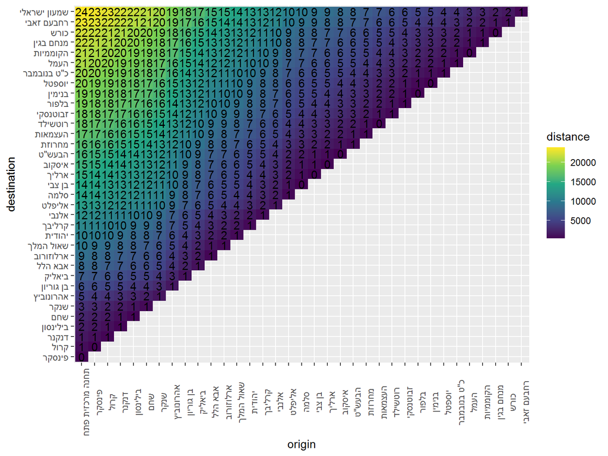

# אבוי - התחנות יושבות על גבולות בין אזורי תנועה

זה הגיוני! אבל חבל, עכשיו יהיה יותר קשה לבצע את הניתוח

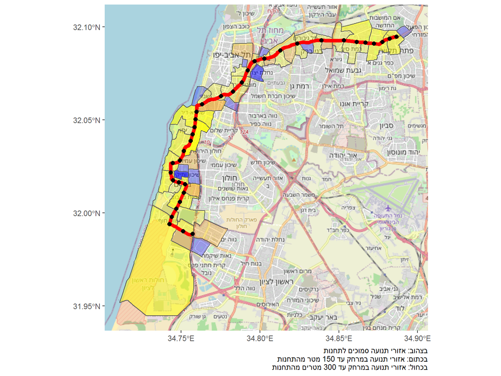

# אוקיי, בואו נשנה כיוון - מרחק אווירי בין אזורי תנועה

לא לגמרי מדויק, אבל זה מה יש

מה נוריד?

נסיעות בתוך אזור

נסיעות בין אזורים שכנים

סקר סלולרי - בעייה עם נסיעות קצרות, ועדיין - בחיבור בין מרכזי אזורים, יש נסיעות קצרות

# התפלגות הנסיעות לאורך הקו האדום לפי מרחק ולפי שעה ביום, לפי הסקר הסלולרי

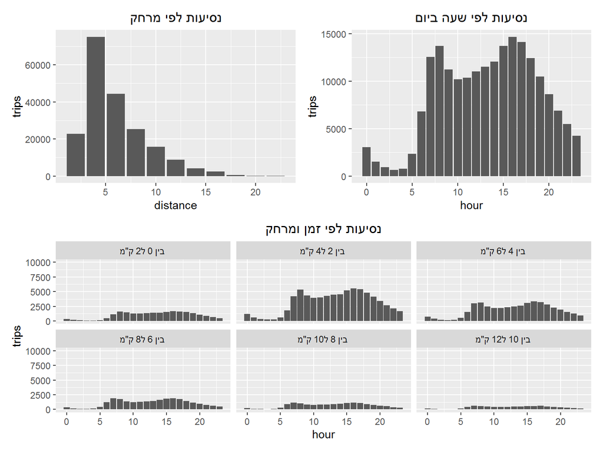

סה"כ 192015 נסיעות

# השוואה לסקר הרגלי נסיעה

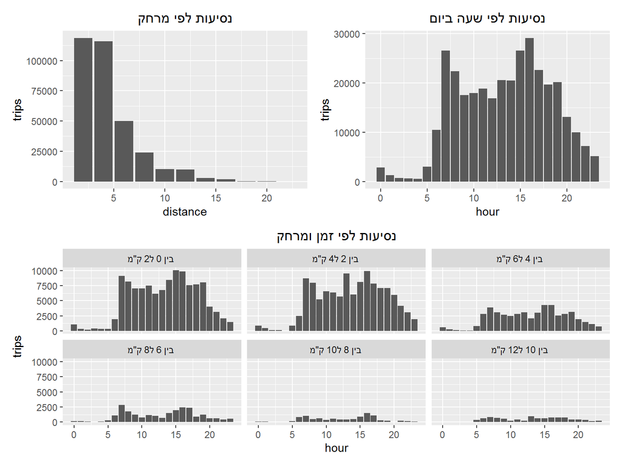

סה"כ 328642 נסיעות

# יש הרבה יותר נסיעות! למה יש פער?

רובו נובע מהנסיעות הקצרות

אבל:

אי אפשר באמת לדעת, ואולי גם בעצם טעיתי בניתוח (אבל אפשר לבדוק אותי כי הקוד חשוף לציבור)

אבל זאת הזדמנות טובה לעמוד על ההבדל המהותי בין הסקרים:

הסקר הסלולרי דוגם כמות עצומה של יחידים, לאורך תקופה ארוכה, ככה שהוא די מהימן

אבל הבעיה שהוא לא דוגם נסיעות קצרות מ1.5 ק"מ, מה שהופך אותו למוטה מבחינת נסיעות קצרות בתוך אזור התנועה

בנוסף, ההגדרה שלו לפעילות במוצא או ביעד תלויה בכמות זמן מסוימת (של 40 דקות), ומכיוון שכך הוא כנראה מפספס פעילויות.

סקר הרגלי נסיעה דוגם כמות קטנה של משתמשי דרך, וגם זאת - ליום או יומיים בלבד ובשנים שונות, אותם מנפחים תחת הנחות ומקבלים הערכה לגבי ההרגלים של כלל האוכלוסיה, מה שעלול להיות לא מדויק בכלל

אבל מצד שני, אפשר לקבל הרבה יותר מידע לגבי אופי הנסיעות והפעילויות מאשר הסקר הסלולרי, למשל:

# מהו הפיצול לפי סקר הרגלי נסיעה?

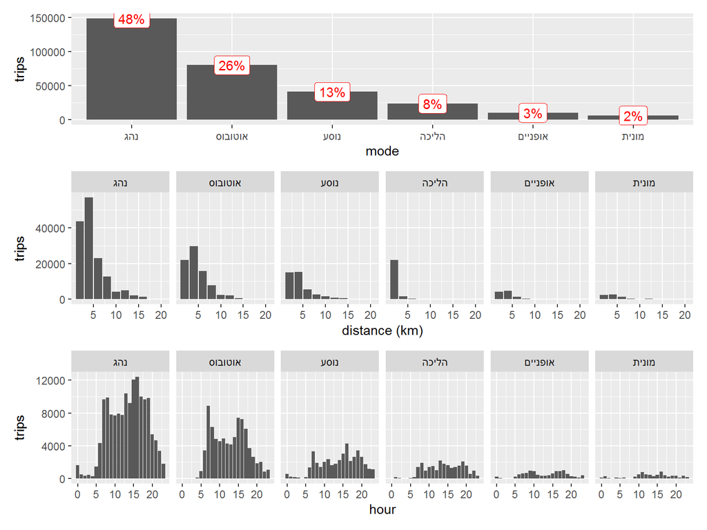

# פילוח לפי מגזר ושעה ביום

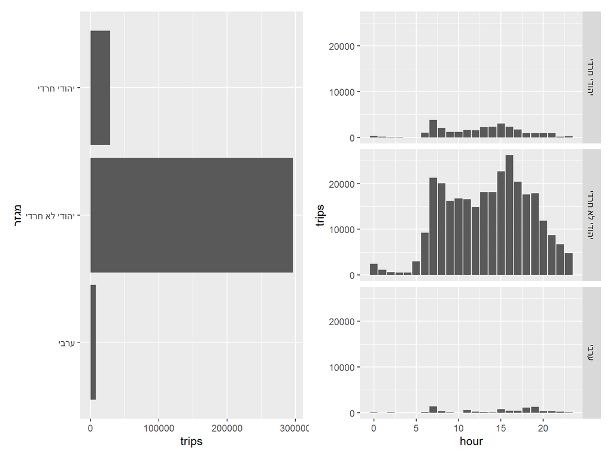

# פילוח לפי גיל, מרחק ושעה ביום

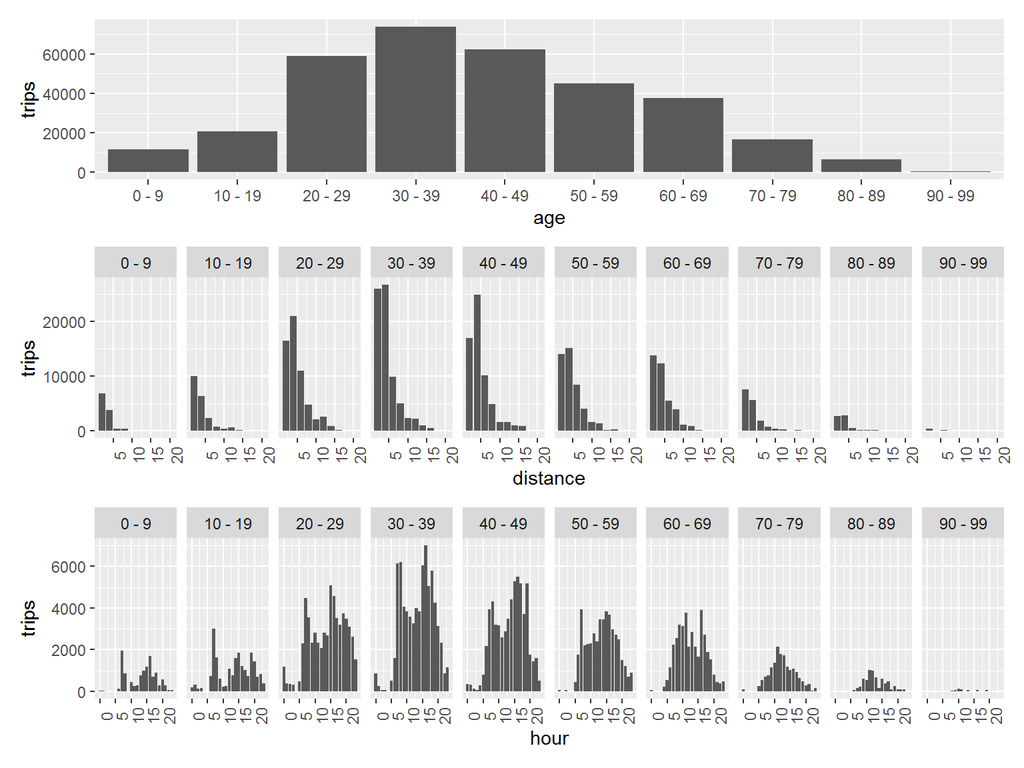

# סיכום

הסקרים נותנים תוצר דומה אך שונה

סקר סלולרי יותר אמין למרחקים גדולים, חסר יכולת ניתוח ופילוח, בעייתי בזיהוי פעילויות

סקר הרגלי נסיעה מסתמך על הנחות מרובות, אבל מאפשר ניתוח של המרחק הקצר, ובין גילאים/מגזרים/אמצעים

שווה לשלב בין יכולות הניתוח

שווה לעשות ניתוח נוסף על קווי רקל/מטרו/אוטובוס אחרים

שווה להכניס עוד ניתוחים מרחביים לניתוח,

או כל שאלה אחרת שאתם חושבים שניתן לענות עליה באמצעות הנתונים

*In god we trust, all else must bring data*

ואני אוסיף - גם להבין את מגבלותיו, *ולשחרר את הניתוח שלנו לציבור הרחב, על כל שלביו, כי תמיד נטעה*

ט.ל.ח. הניתוח הנ"ל נעשה לצורכי הדגמה בלבד. אין להסיק ממנו מסקנות כאלה או אחרות.